# AA18.1: Découverte du tidyverse

## Représentation de plusieurs `geom`

On peut représenter plusieurs `geom` simultanément sur un même graphique, il suffit de les ajouter à tour de rôle avec l’opérateur `+`.

Par exemple, on peut supecooser la position des points au-dessus d’un graphique en boîtes à moustaches. On va pour cela ajouter un `geom_point` après avoir ajouté notre `geom_boxplot` :

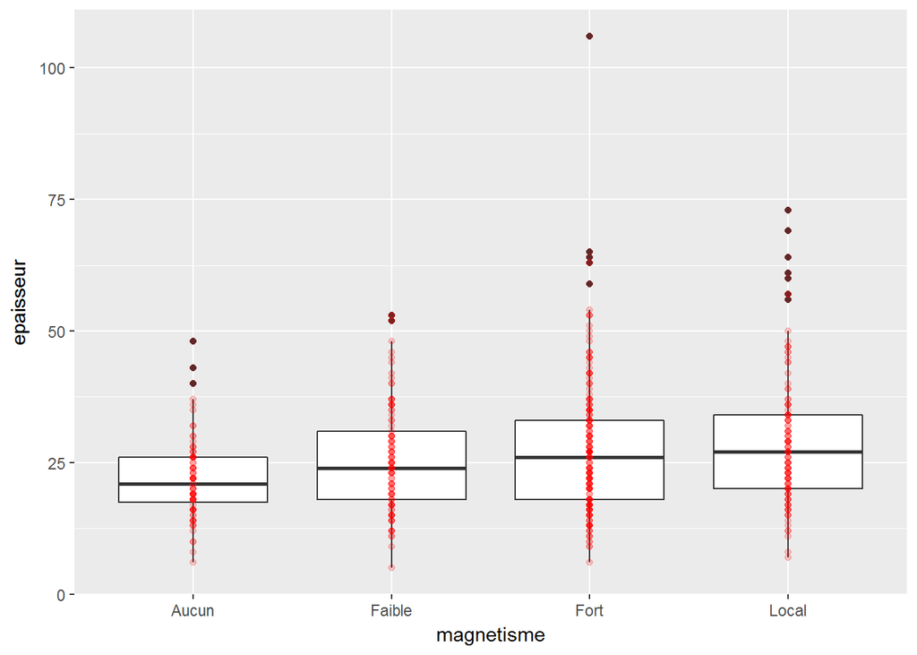

```r
ggplot(co) +
  geom_boxplot(aes(x = magnetisme, y = epaisseur)) +
  geom_point(aes(x = magnetisme, y = epaisseur), col = "red", alpha = 0.2)
```

> Quand une commande `ggplot2` devient longue, il peut être plus lisible de la répartir sur plusieurs lignes. Dans ce cas, il faut penser à placo l’opérateur `+` en fin de ligne, afin que R comprenne que la commande n’est pas complète et prenne en compte la suite.

Pour un résultat un peu plus lisible, on peut remplaco `geom_point` par `geom_jitter`, qui disperse les points horizontalement et facilite leur visualisation :

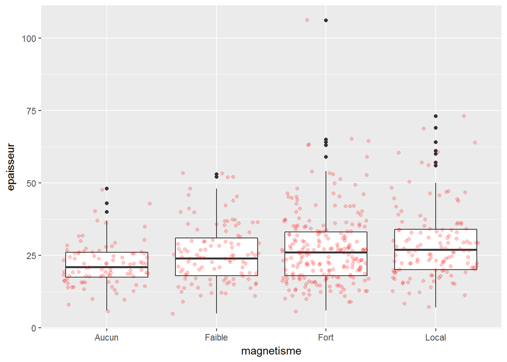

```r
ggplot(co) +
  geom_boxplot(aes(x = magnetisme, y = epaisseur)) +
  geom_jitter(aes(x = magnetisme, y = epaisseur), col = "red", alpha = 0.2)
```

Dans ce cas, plutôt que de déclarer les mappages dans chaque `geom`, on peut les déclarer dans l’appel à `ggplot()`. Ils seront automatiquement “hérités” par les `geom` ajoutés (sauf s’ils redéfinissent les mêmes mappages) :

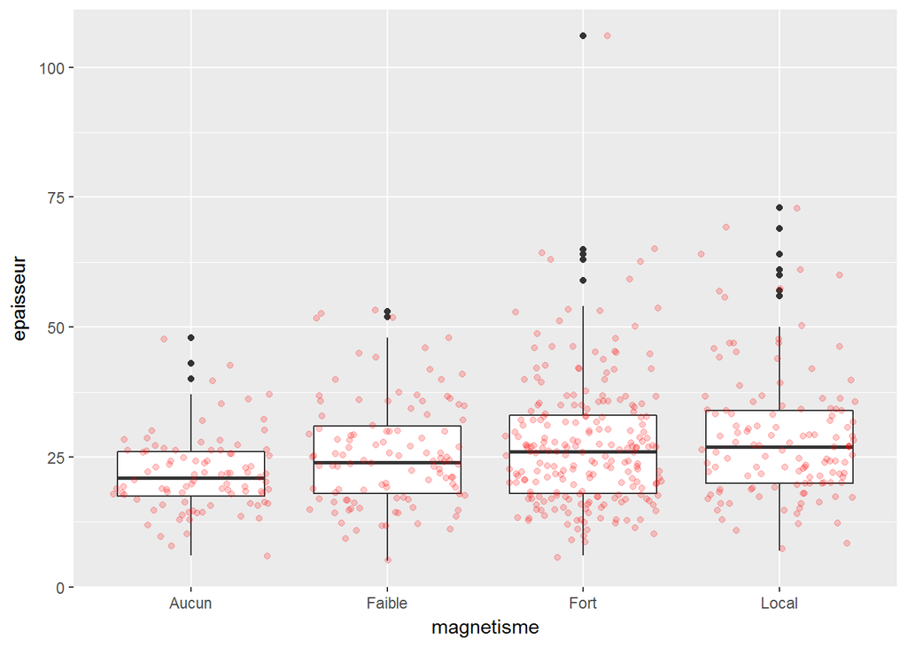

```r
ggplot(co, aes(x = magnetisme, y = epaisseur)) +
  geom_boxplot() +
  geom_jitter(color = "red", alpha = 0.2)
```

Autre exemple, on peut vouloir ajouter à un nuage de points une ligne de régression linéaire à l’aide de `geom_smooth` :

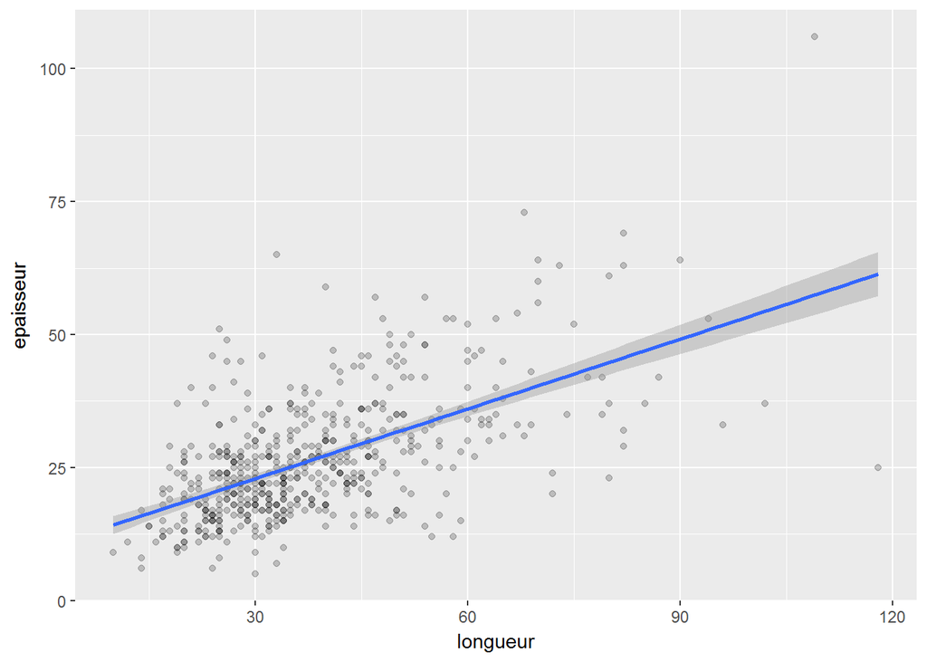

```r
ggplot(co, aes(x = longueur, y = epaisseur)) +
  geom_point(alpha = 0.2) +
  geom_smooth(method = "lm")
```

Et on peut même supecooser une troisième visualisation de la répartition des points dans l’espace avec `geom_density2d` :

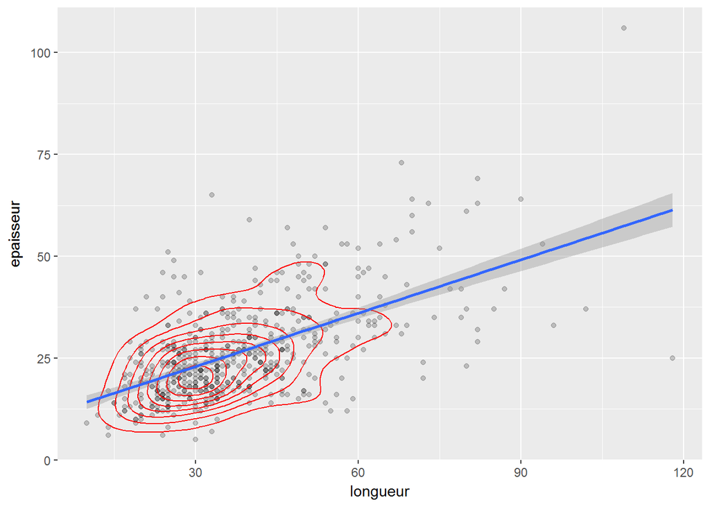

```r
ggplot(co, aes(x = longueur, y = epaisseur)) +
  geom_point(alpha = 0.2) +
  geom_density2d(color = "red") +
  geom_smooth(method = "lm")
```

### Plusieurs sources de données

On peut aussi associer à différents `geom` des sources de données différentes. Supposons qu’on souhaite afficher sur un nuage de points les id des scories d’aspect lisse. On peut commenco par créer un tableau de données avec seulement ces scories `filter` :

```r
co50 <- filter(co, aspect == "Lisse")
```

On fait ensuite le nuage de points comme précédemment :

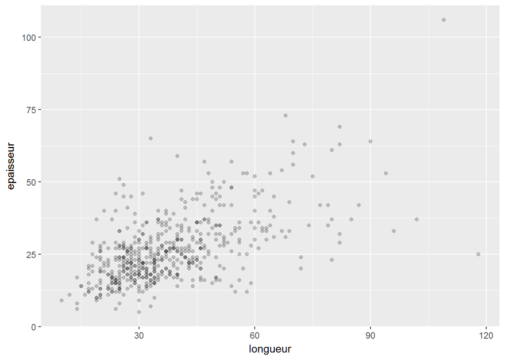

```r
ggplot(data = co, aes(x = longueur, y = epaisseur)) +
  geom_point(alpha = 0.2)
```

Pour supecooser les noms des cories d’aspect lisse, on peut ajouter un `geom_text`, mais en spécifiant que les données proviennent du nouveau tableau `com50` et non de notre tableau initial `co`. On le fait en passant un argument `data` spécifique à `geom_text` :

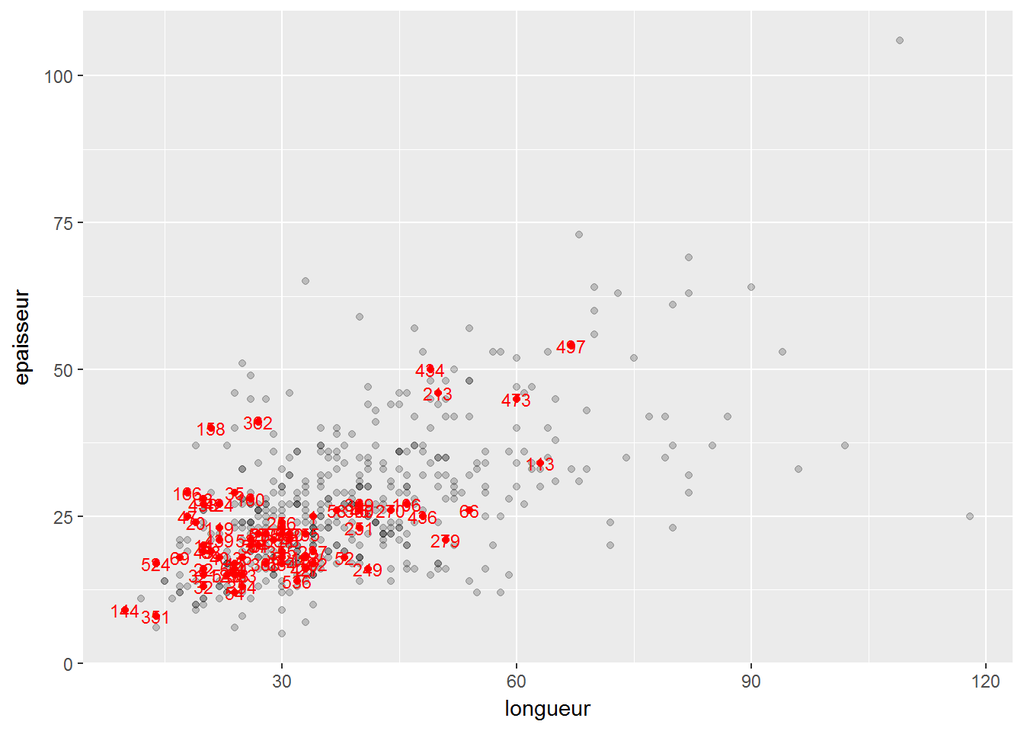

```r
ggplot(data = co, aes(x = longueur, y = epaisseur)) +
  geom_point(alpha = 0.2) +
  geom_text(data = co50, aes(label = id),color = "red", size = 3) +
  geom_point(data = co50, color ="red")
```

Ainsi, on a un graphique avec deux `geom` supecoosés, mais dont les données proviennent de deux tableaux différents.

## Faceting

Le *faceting* permet d’effectuer plusieurs fois le même graphique selon les valeurs d’une ou plusieurs variables qualitatives.

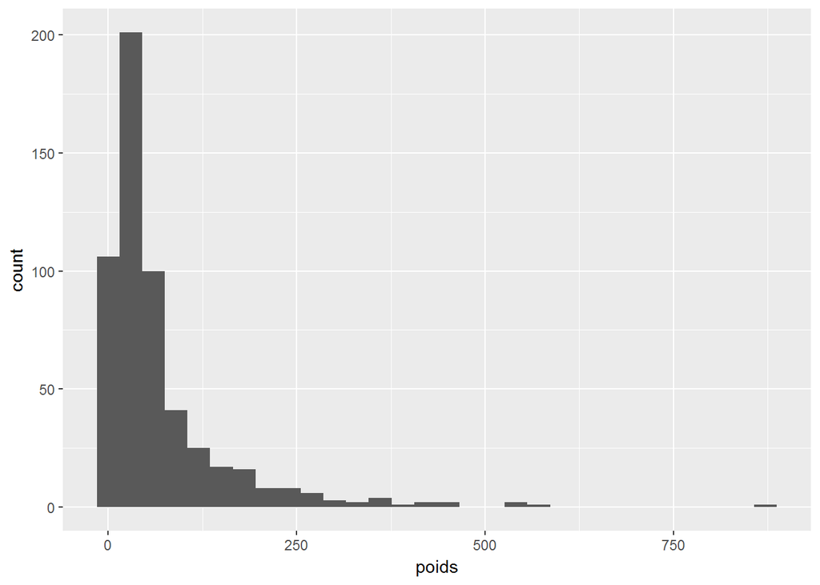

```r
ggplot(data = co) +
  geom_histogram(aes(x = poids))
```

Avec `facet_wrap`, les différents graphiques sont affichés les uns à côté des autres et répartis automatiquement dans la page. Par exemple :

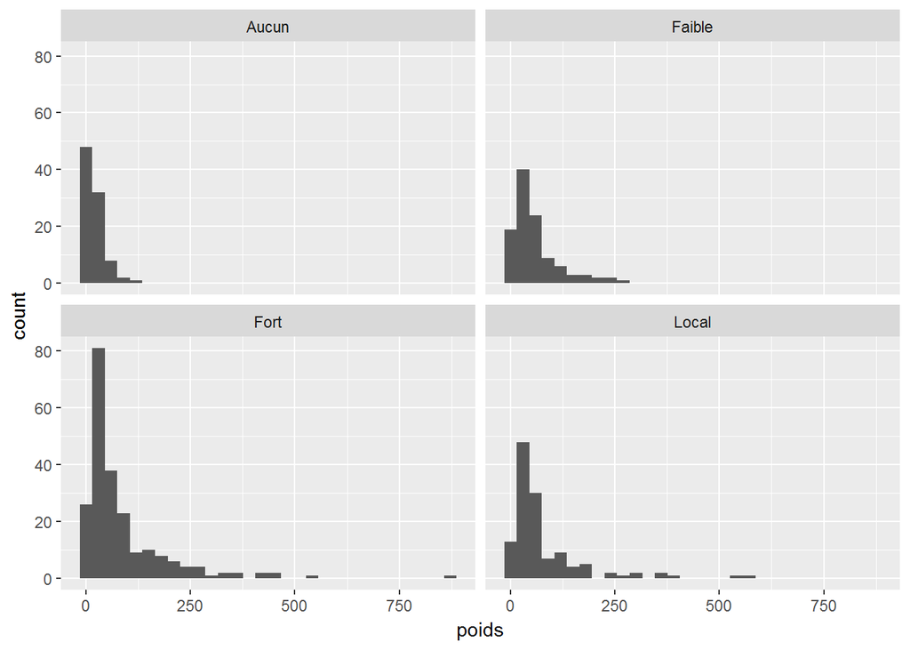

```r
ggplot(data = co) +
  geom_histogram(aes(x = poids)) +
  facet_wrap(~magnetisme)
```

Pour `facet_grid`, les graphiques sont disposés selon une grille. La formule est alors de la forme `variable en ligne ~ variable en colonne`. Si on n’a pas de variable dans l’une des deux dimensions, on met un point (`.`) :

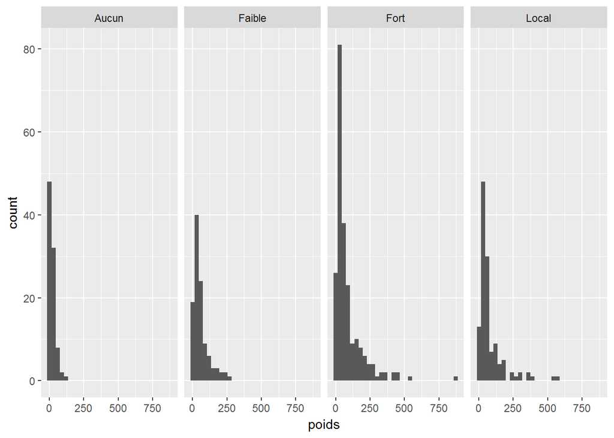

```r
ggplot(data = co) +
  geom_histogram(aes(x = poids)) +
  facet_grid(.~magnetisme)
```

Un des intérêts du faceting dans `ggplot2` est que tous les graphiques générés ont les mêmes échelles, ce qui permet une comparaison directe.

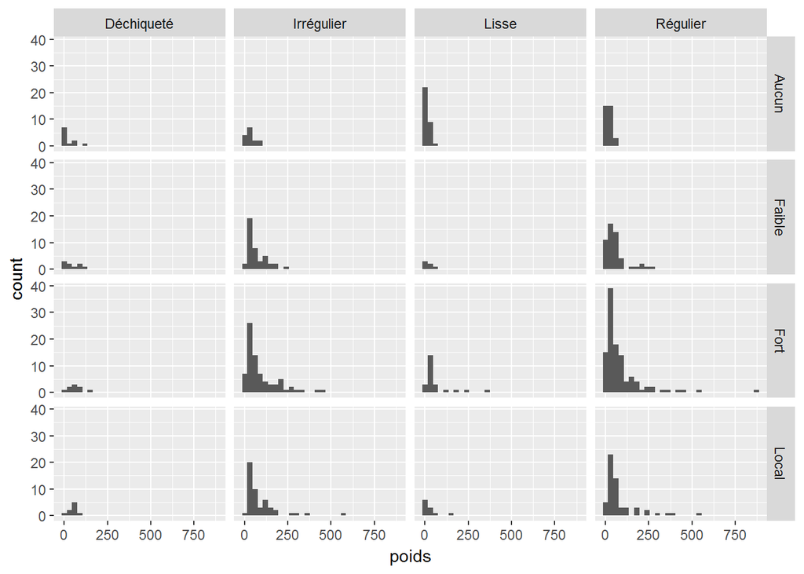

```r
ggplot(data = co) +
  geom_histogram(aes(x = poids)) +
  facet_grid(magnetisme~aspect)
```

## Scales

On a vu qu’avec `ggplot2` on définissait des mappages entre des attributs graphiques (position, taille, couleur, etc.) et des variables d’un tableau de données. Ces mappages sont définis, pour chaque `geom`, via la fonction `aes()`.

Les *scales* dans `ggplot2` permettent de modifier la manière dont un attribut graphique va être relié aux valeurs d’une variable, et dont la légende correspondante va être affichée. Par exemple, pour l’attribut `color`, on pourra définir la palette de couleur utilisée. Pour `size`, les tailles minimales et maximales, etc.

Pour modifier une *scale* existante, on ajoute un nouvel élément à notre objet `ggplot2` avec l’opérateur `+`. Cet élément prend la forme `scale_<attribut>_<type>`.

Voyons tout de suite quelques exemples.

### `scale_size`

Si on souhaite modifier les tailles minimales et maximales des objets quand on a effectué un mappage de type `size`, on peut utiliser la fonction `scale_size` et son argument `range` :

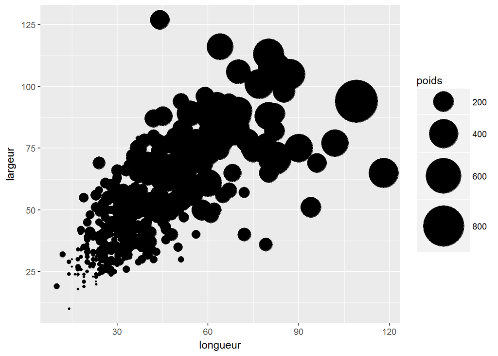

```r
ggplot(co) +
  geom_point(aes(x = longueur, y = largeur, size = poids)) +
  scale_size(range = c(0,20))
```

À comparer par exemple à :

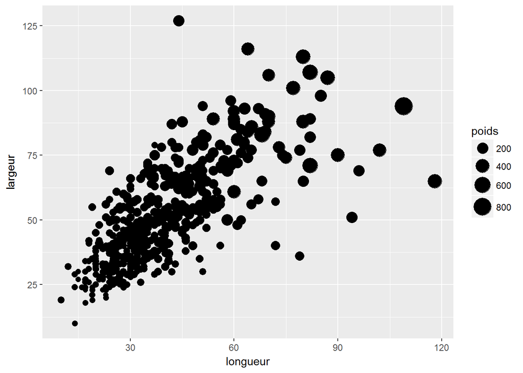

```r
ggplot(co) +
  geom_point(aes(x = longueur, y = largeur, size = poids)) +
  scale_size(range = c(2,8))
```

On peut ajouter d’autres paramètres à `scale_size`. Le premier argument est toujours le titre donné à la légende :

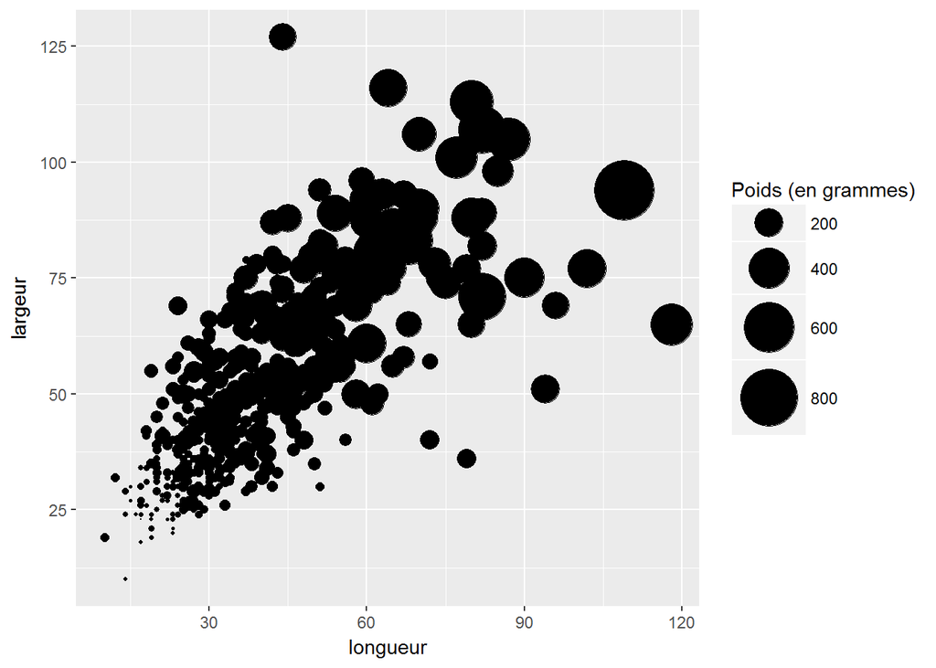

```r
ggplot(co) +
  geom_point(aes(x = longueur, y = largeur, size = poids)) +
  scale_size("Poids (en grammes)", range = c(0,15))
```

On peut aussi définir manuellement les éléments de légende représentés :

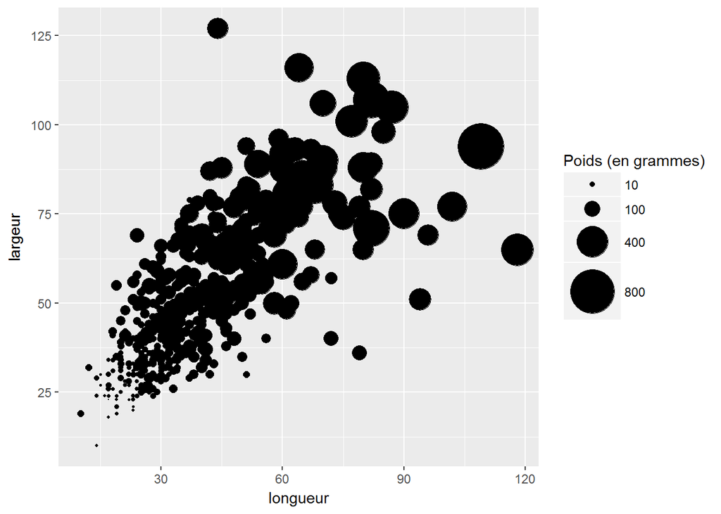

```r
ggplot(co) +
  geom_point(aes(x = longueur, y = largeur, size = poids)) +
  scale_size("Poids (en grammes)", range = c(0,15), breaks = c(10,100,400,800))
```

### `scale_x`, `scale_y`

Les *scales* `scale_x` et `scale_y` modifient les axes `x` et `y` du graphique.

`scale_x_continuous` et `scale_y_continuous` s’appliquent lorsque la variable `x` ou `y` est numérique (quantitative).

C’est le cas de notre nuage de points croisant longueur et largeurs des cories de culot :

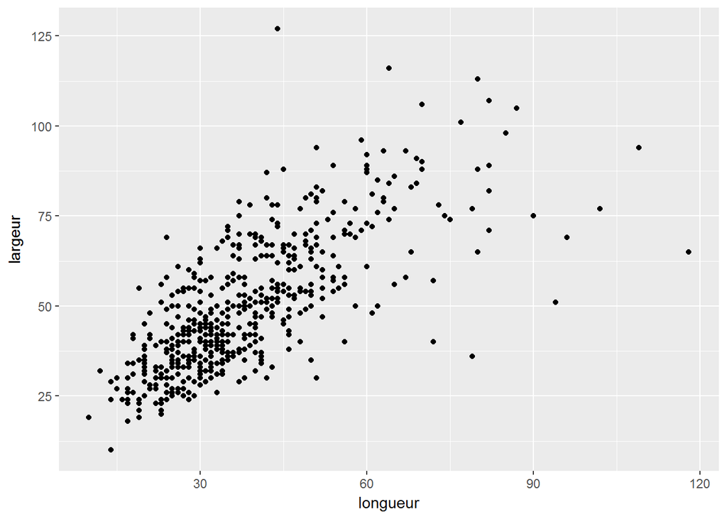

```r
ggplot(co) +
  geom_point(aes(x = longueur, y = largeur))
```

On peut vouloir forco les axes `x` et `y` à s’étendre des valeurs 0 à 150. On peut le faire en ajoutant un élément `scale_x_continuous` et un élément `scale_y_continuous`, et en utilisant leur argument `limits` :

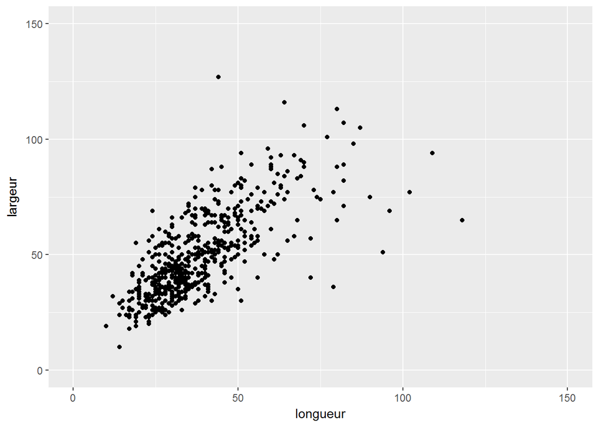

```r
ggplot(co) +
  geom_point(aes(x = longueur, y = largeur)) +
  scale_x_continuous(limits = c(0,150)) +
  scale_y_continuous(limits = c(0,150))
```

Là aussi, on peut modifier les étiquettes des axes en indiquant une chaîne de caractères en premier argument :

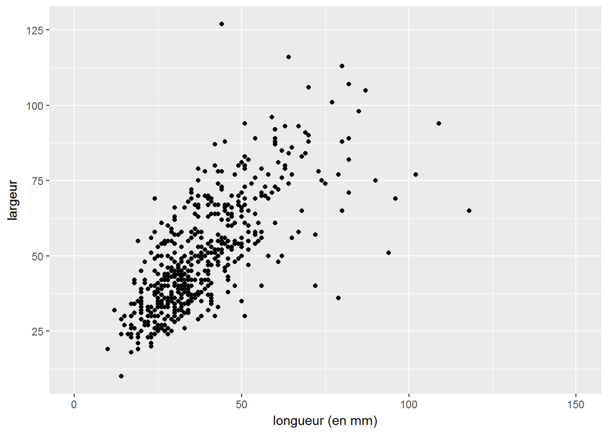

```r
ggplot(co) +
  geom_point(aes(x = longueur, y = largeur)) +
  scale_x_continuous("longueur (en mm)", limits = c(0,150))
```

On peut utiliser `scale_x_log10` et `scale_y_log10` pour passer un axe à une échelle logarithmique : (Attention il n’y a pas d’interêt ici pour ce jeu de données..)

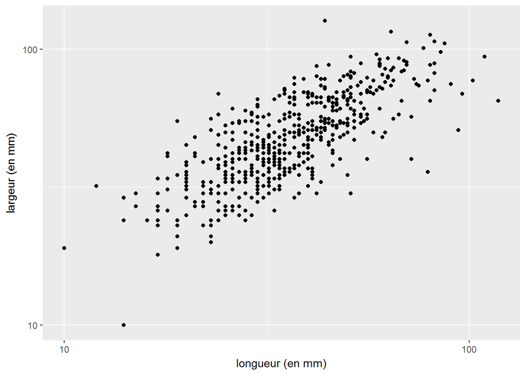

```r
ggplot(co) +
  geom_point(aes(x = longueur, y = largeur)) +
  scale_x_log10("longueur (en mm)")+
  scale_y_log10("largeur (en mm)")
```

`scale_x_discrete` et `scale_y_discrete` s’appliquent quant à elles lorsque l’axe correspond à une variable discrète (qualitative). C’est le cas de l’axe des `x` dans un diagramme en bâtons :

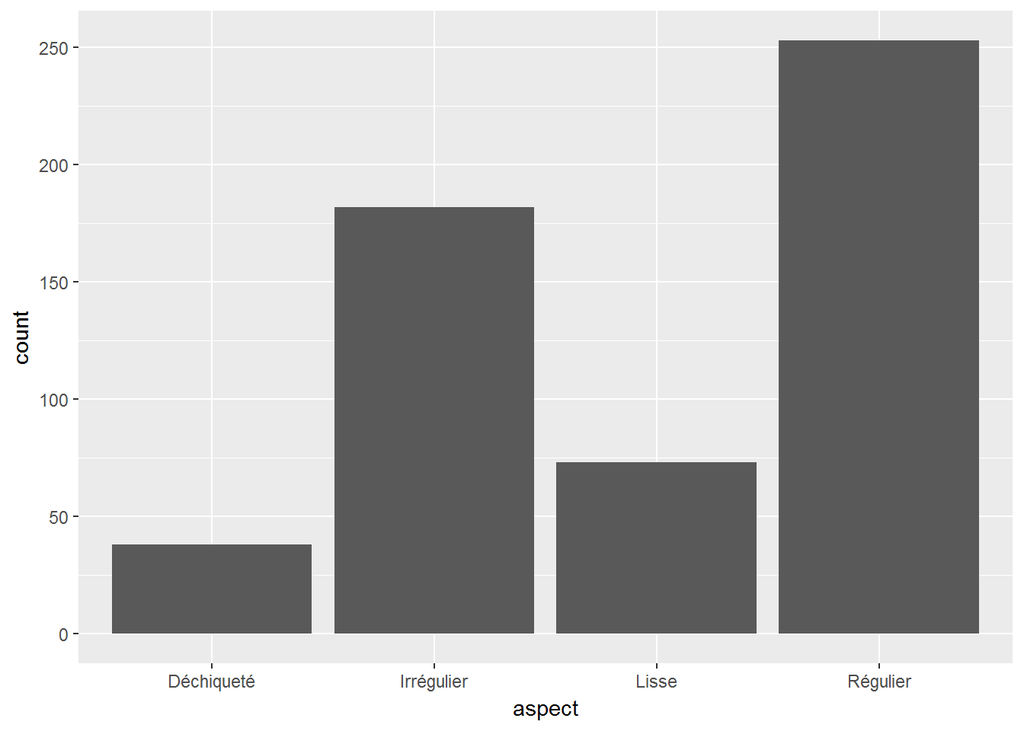

```r
ggplot(co) +
  geom_bar(aes(x = aspect)) +
  scale_x_discrete("aspect")
```

L’argument `limits` de `scale_x_discrete` permet d’indiquer quelles valeurs sont affichées et dans quel ordre.

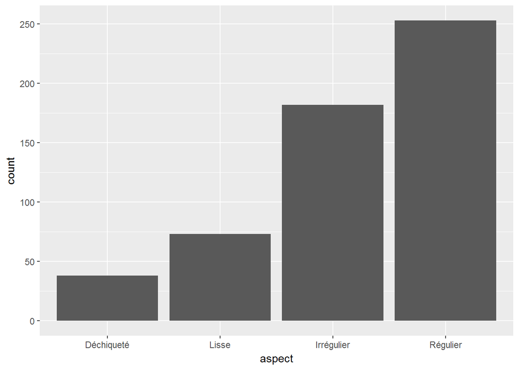

```r
ggplot(co) +
  geom_bar(aes(x = aspect)) +
  scale_x_discrete("aspect", limits = c("Déchiqueté", "Lisse", "Irrégulier", "Régulier"))
```

### `scale_color`, `scale_fill`

Ces *scales* permettent, entre autre, de modifier les palettes de couleur utilisées pour le dessin (`color`) ou le remplissage (`fill`) des éléments graphiques. Dans ce qui suit, pour chaque fonction `scale_color` présentée il existe une fonction `scale_fill` équivalente et avec en général les mêmes arguments.

#### Variables quantitatives

Le graphique suivant colore les points selon la valeur d’une variable numérique quantitative (ici le Poids) :

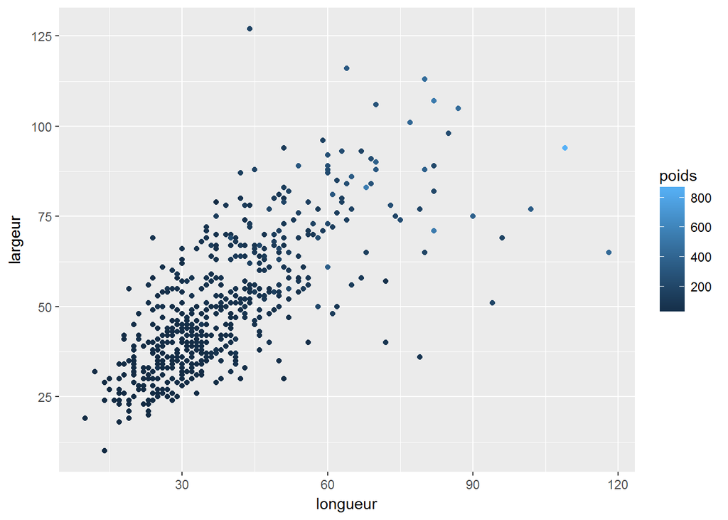

```r
ggplot(co) +
  geom_point(aes(x = longueur, y = largeur, color = poids))
```

On peut modifier les couleurs utilisées avec les arguments `low` et `high` de la fonction `scale_color_gradient`. Ici on souhaite que la valeur la plus faible soit blanche, et la plus élevée rouge :

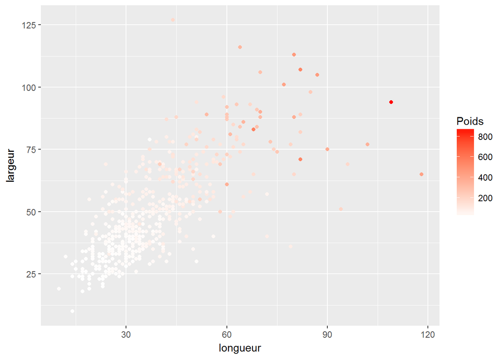

```r
ggplot(co) +
  geom_point(aes(x = longueur, y = largeur, color = poids)) +
  scale_color_gradient("Poids", low = "white", high = "red")
```

On peut aussi utiliser des palettes prédéfinies. L’une des plus populaires est la palette *viridis*, accessible depuis l’extension du même nom. On l’ajoute en utilisant `scale_color_viridis` : Attention: il faut d’abord télecharger le package “viridis” !

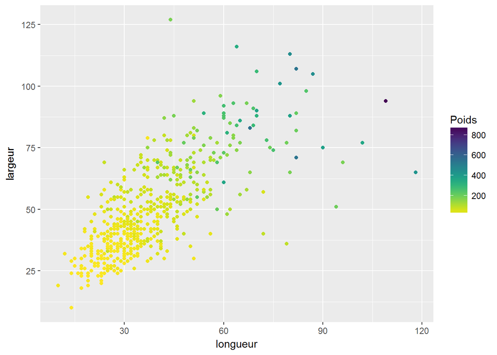

```r
# install.packages("viridis")
library(viridis)
ggplot(co) +
  geom_point(aes(x = longueur, y = largeur, color = poids)) +
  scale_color_viridis("Poids", direction = -1)
```

L’extension `viridis` propose également trois autres palettes, *magma*, *inferno* et *plasma*, accessibles via l’argument `option` :

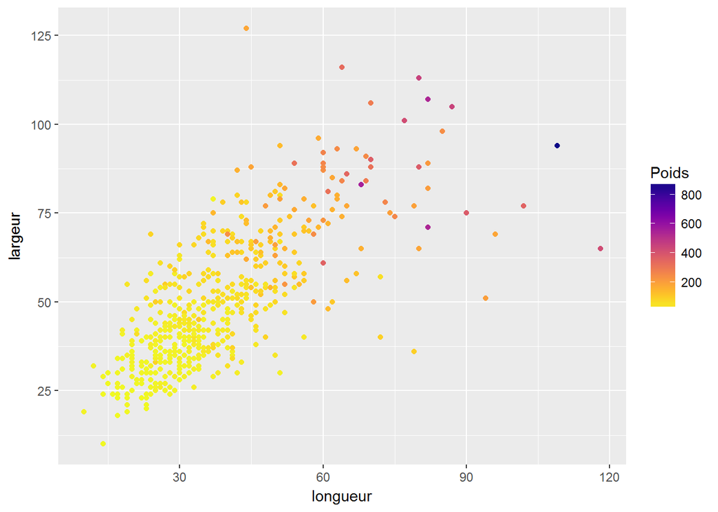

```r
ggplot(co) +
  geom_point(aes(x = longueur, y = largeur, color = poids)) +
  scale_color_viridis("Poids", option = "plasma", direction = -1)
```

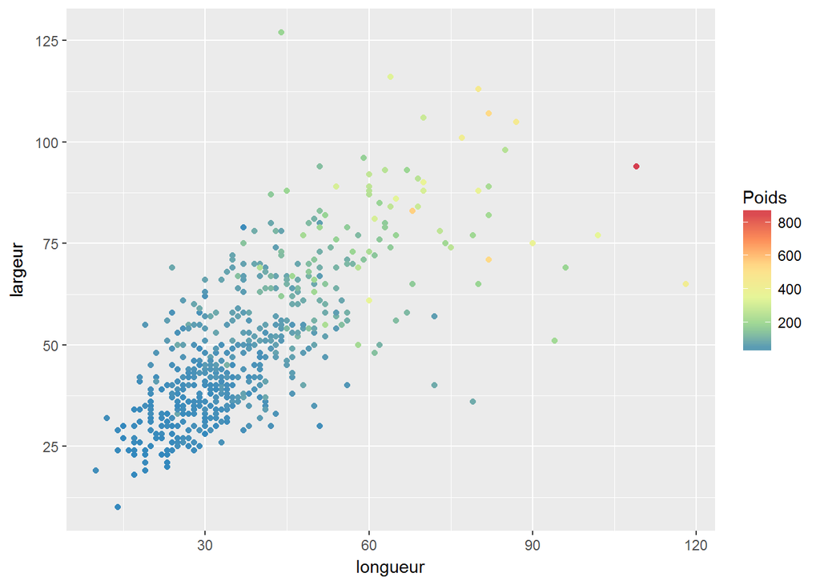

```r
ggplot(co) +
  geom_point(aes(x = longueur, y = largeur, color = poids)) +
  scale_color_distiller("Poids", palette = "Spectral", direction = -1)
```

La liste des palettes de `scale_color_brewer` est indiquée en fin de section suivante.

#### Variables qualitatives

Si on a fait un mappage avec une variable discrète (qualitative), comme ici avec le magnétisme :

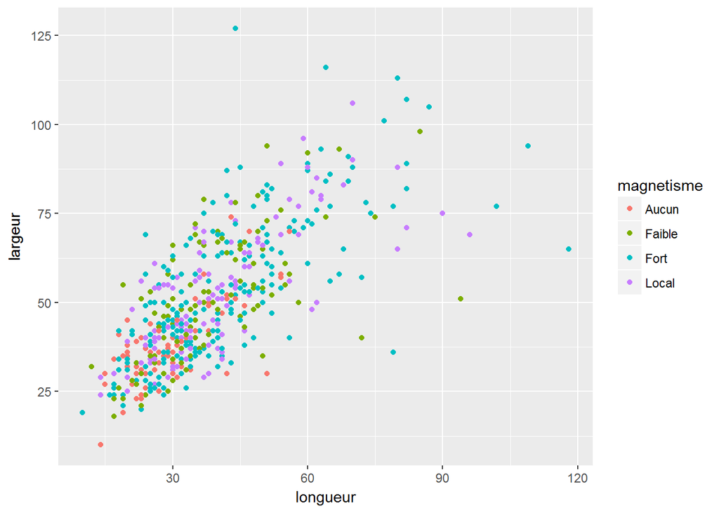

```r
ggplot(co) +
  geom_point(aes(x = longueur, y = largeur, color = magnetisme))
```

Une première possibilité est de modifier la palette manuellement avec `scale_color_manual` et son argument `values` :

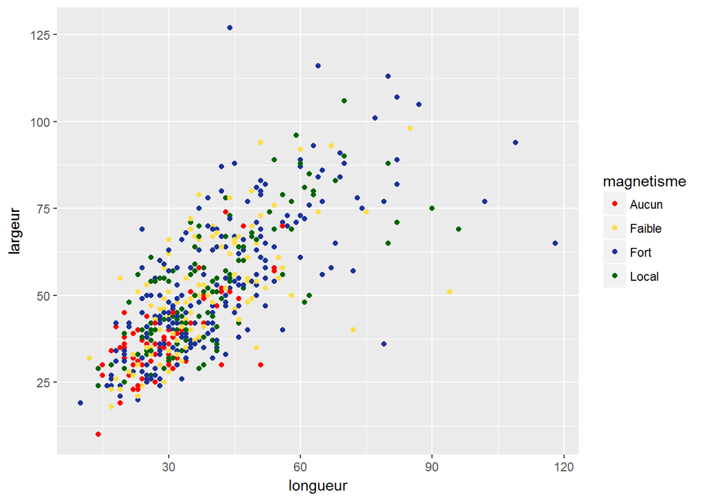

```r
ggplot(co) +
  geom_point(aes(x = longueur, y = largeur, color = magnetisme)) +
  scale_color_manual("magnetisme",
                     values = c("red", "#FFDD45", rgb(0.1,0.2,0.6), "darkgreen", "grey80"))
```

> L’exemple précédent montre plusieurs manières de définir manuellement des couleurs dans R : - Par code hexadécimal : `"#FFDD45"` - En utilisant la fonction `rgb` et en spécifiant les composantes rouge, vert, bleu par des nombres entre 0 et 1 (et optionnellement une quatrième composante d’opacité, toujours entre 0 et 1) : `rgb(0.1,0.2,0.6)` - En donnant un nom de couleur : `"red"`, `"darkgreen"`

> La liste complète des noms de couleurs connus par R peut être obtenu avec la fonction `colors()`. Vous pouvez aussi retrouver en ligne [la liste des couleurs et leur nom](http://www.stat.columbia.edu/~tzheng/files/Rcolor.pdf) (PDF).

Il est cependant souvent plus pertinent d’utiliser des palettes prédéfinies. Celles du site [Colorbrewer](http://colorbrewer2.org/), initialement prévues pour la cartographie, permettent une bonne lisibilité, et peuvent être adaptées pour cotains types de daltonisme.

Ces palettes s’utilisent via la fonction `scale_color_brewer`, en passant le nom de la palette via l’argument `palette`. Par exemple, si on veut utiliser la palette `Set1` :

Attention: il faut installer préalablement le package “RColorBrewer”"

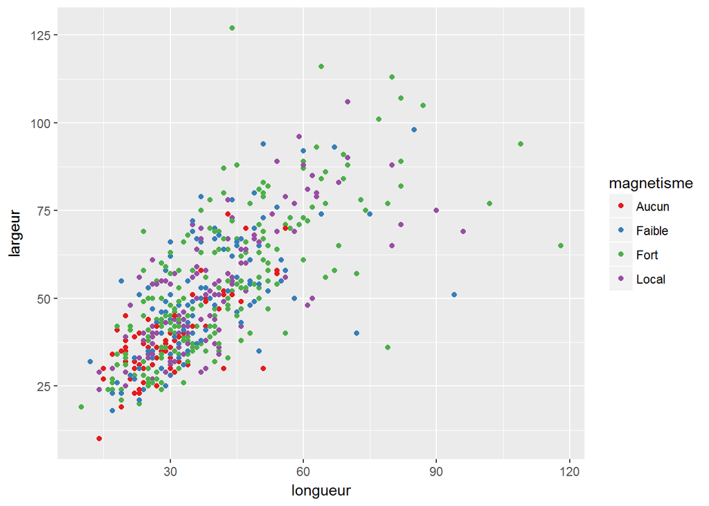

```r
# install.packages("RColorBrewer")
ggplot(co) +
  geom_point(aes(x = longueur, y = largeur, color = magnetisme)) +
  scale_color_brewer("magnetisme", palette = "Set1")
```

Le graphique suivant, accessible via la fonction `display.brewer.all()`, montre la liste de toutes les palettes disponibles via `scale_color_brewer`. Elles sont réparties en trois familles : les palettes séquentielles (pour une variable quantitative), les palettes qualitatives, et les palettes divergentes (typiquement pour une variable quantitative avec une valeur de référence, souvent 0, et deux palettes continues distinctes pour les valeurs inférieures et pour les valeurs supérieures).

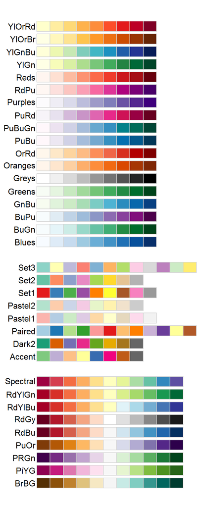

```r
RColorBrewer::display.brewer.all()
```

Il existe d’autres méthodes pour définir les couleurs : pour plus d’informations on pourra se reporter à [l’article de la documentation officielle sur ce sujet](http://ggplot2.tidyverse.org/articles/ggplot2-specs.html#colour).

## Thèmes

Les thèmes permettent de contrôler l’affichage de tous les éléments du graphique qui ne sont pas reliés aux données : titres, grilles, fonds, etc.

Il existe un cotain nombre de thèmes préexistants, par exemple le thème `theme_bw` :

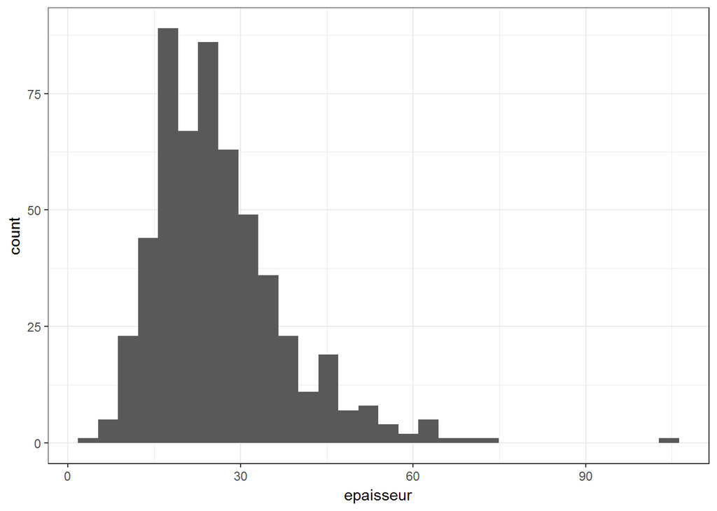

```r
ggplot(data = co) +
  geom_histogram(aes(x = epaisseur)) +
  theme_bw()
```

Ou le thème `theme_minimal` :

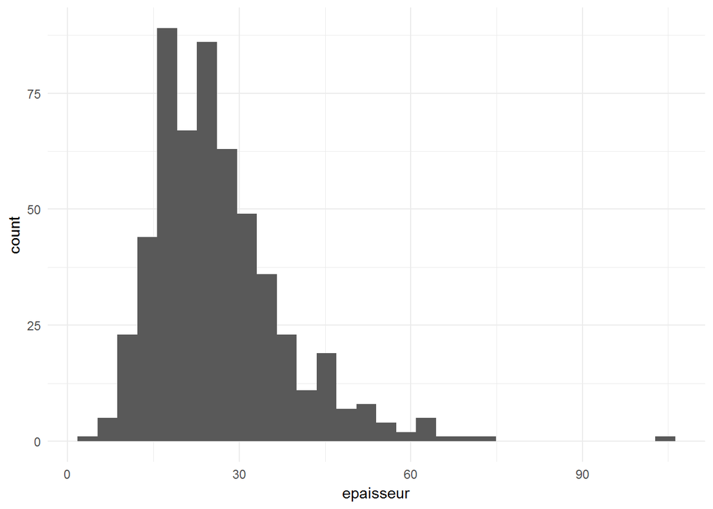

```r
ggplot(data = co) +
  geom_histogram(aes(x = epaisseur)) +
  theme_minimal()
```

On peut cependant modifier manuellement les différents éléments. Par exemple, les fonctions `ggtitle`, `xlab` et `ylab` permettent d’ajouter ou de modifier le titre du graphique, ainsi que les étiquettes des axes `x` et `y` :

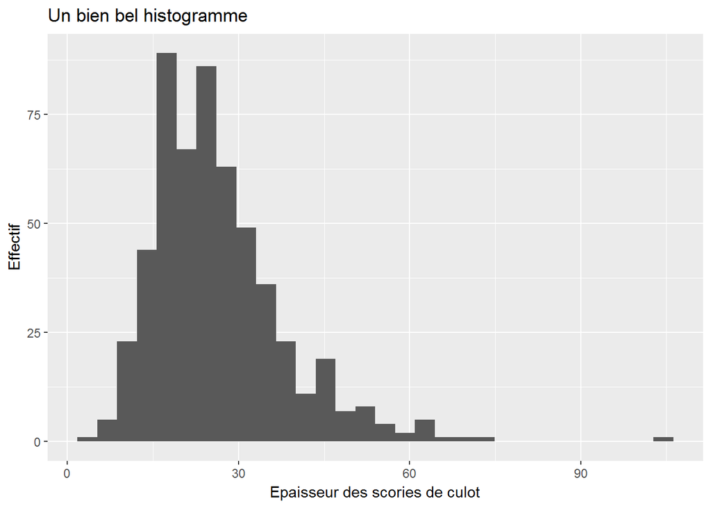

```r
ggplot(data = co) +
  geom_histogram(aes(x = epaisseur)) +
  ggtitle("Un bien bel histogramme") +
  xlab("Epaisseur des scories de culot") +
  ylab("Effectif")
```

Les éléments personnalisables étant nombreux, un bon moyen de se familiariser avec tous les arguments est sans doute l’addin RStudio `ggThemeAssist`. Pour l’utiliser il suffit d’installer le package du même nom, de sélectionner dans son script RStudio le code correspondant à un graphique `ggplot2`, puis d’aller dans le menu *Addins* et choisir *ggplot Theme Assistant*. Une interface graphique s’affiche alors permettant de modifier les différents éléments. Si on clique sur *Done*, le code sélectionné dans le script est alors automatiquement mis à jour pour correspondre aux modifications effectuées.

Ce qui permet d’obtenir très facilement des résultats extrêmement moches :

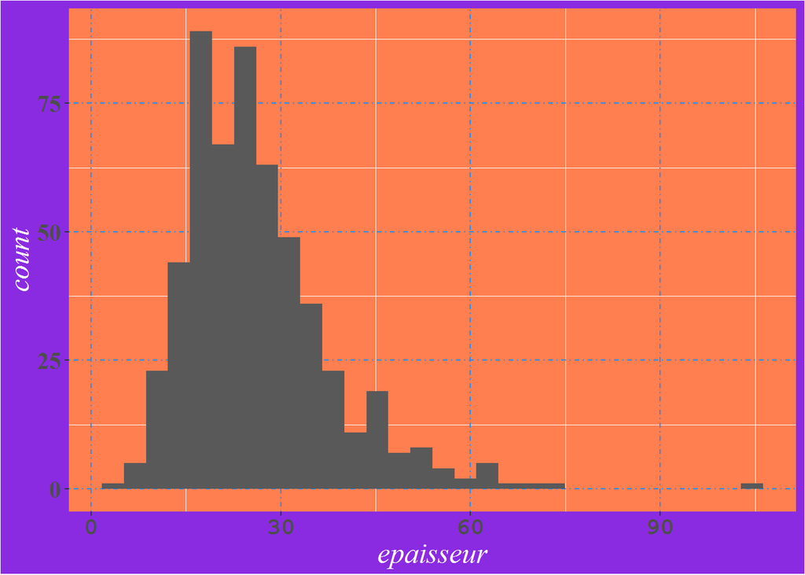

```r
ggplot(data = co) + geom_histogram(aes(x = epaisseur)) +
 theme(panel.grid.major = element_line(colour = "dodgerblue",
    size = 0.5, linetype = "dotdash"), axis.title = element_text(family = "serif",
    size = 18, face = "italic", colour = "white"),
    axis.text = element_text(family = "serif",
        size = 15, face = "bold"), axis.text.x = element_text(family = "mono"),
    plot.title = element_text(family = "serif"),
    legend.text = element_text(family = "serif"),
    legend.title = element_text(family = "serif"),
    panel.background = element_rect(fill = "coral"),
    plot.background = element_rect(fill = "blueviolet"))
```

## Ressources

[La documentation officielle](http://ggplot2.tidyverse.org/index.html) (en anglais) de `ggplot2` est très complète et accessible en ligne.

Une “antisèche” (en anglais) résumant en deux pages l’ensemble des fonctions et arguments et disponible soit directement depuis RStudio (menu *Help > Chetasheets > Data visualization with ggplot2*) ou [directement en ligne](https://www.rstudio.com/resources/cheatsheets/)

Les parties [Data visualisation](http://r4ds.had.co.nz/data-visualisation.html) et [Graphics for communication](http://r4ds.had.co.nz/graphics-for-communication.html) de l’ouvrage en ligne *R for data science*, de Hadley Wickham, sont une très bonne introduction à `ggplot2`.

Plusieurs ouvrages, toujours en anglais, abordent en détail l’utilisation de `ggplot2`, en particulier [ggplot2: Elegant Graphics for Data Analysis](http://www.amazon.fr/ggplot2-Elegant-Graphics-Data-Analysis/dp/0387981403/), toujours de Hadley Wickham, et le [R Graphics Cookbook](http://www.amazon.fr/R-Graphics-Cookbook-Winston-Chang/dp/1449316956) de Winston Chang.

Le [site associé](http://www.cookbook-r.com/Graphs/) à ce dernier ouvrage comporte aussi pas mal d’exemples et d’informations intéressantes.

Enfin, si `ggplot2` présente déjà un très grand nombre de fonctionnalités, il existe aussi un système d’extensions permettant d’ajouter des `geom`, des thèmes, etc. Le site [ggplot2 extensions](http://www.ggplot2-exts.org/) est une très bonne ressource pour les parcourir et les découvrir, notamment grâce à sa [galerie](http://www.ggplot2-exts.org/gallery/).